# Heart Disease Mortality in Scotland

by: Zhuohang Li, Zihan Kong, Wenjie Li, Kitty Hou

2026-11-27

## Research Question

As the years progress, how do demographic factors (age and sex) and geographical location (Council Areas) influence heart disease mortality rates in Scotland? Understanding these differences is critical for public health planning. By identifying which demographic groups are most vulnerable and which regions experience disproportionately higher mortality rates, policymakers and healthcare providers can better allocate resources and design targeted interventions to reduce heart disease mortality across Scotland.

## Data Overview

The dataset for this investigation is sourced from the Scottish Heart Disease Statistics published by Public Health Scotland, containing mortality records categorised by Council Areas from 2015 to 2024 (with 2024 figures marked as provisional). During the data wrangling process using the tidyverse package, we joined the raw mortality dataset with the Data Zone 2022 lookup dictionary to convert alphanumeric zone codes into readable Council Area names, removed missing entries, and filtered specifically for Coronary Heart Disease (CHD) as our primary focus.

The cleaned dataset focuses on the following key variables:

1. Year (year): Calendar year of death registration (2015–2024). For statistical modelling, we restricted the timeframe to 2015–2023 to avoid bias from provisional 2024 figures.
2. Sex (gender): Biological sex differentiating male and female mortality (Male, Female, and All).
3. Age Group (age_group): Demographic age brackets (0-44 years, 45-64 years, 65-74 years, 75plus years, and All Ages).
4. Area (area): The 32 Scottish Council Areas alongside the national aggregate (Scotland).
5. Mortality Metrics (easr and crude_rate): We use the European Age-Standardised Mortality Rate (easr, per 100,000 population) for regional comparisons to control for differing age structures across Council Areas, and the Crude Mortality Rate (crude_rate, per 100,000 population) for age- and sex-specific analyses.

## Exploratory Data Analysis

### National Mortality Trend (2015–2024)

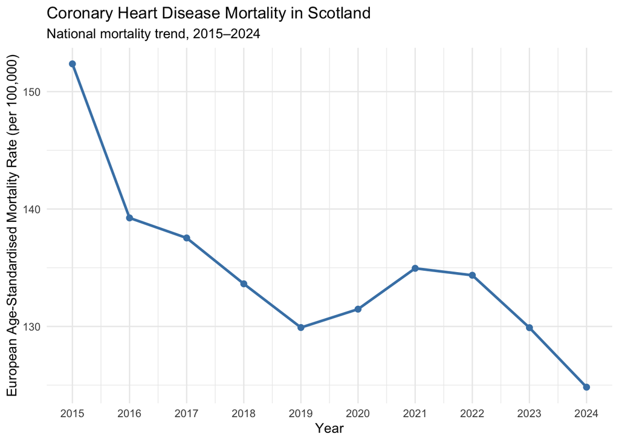

### Demographic Differences: Age and Sex

Breaking down national crude mortality rates by age group and sex reveals strong demographic disparities:

Age Group: Mortality rates rise sharply with age. While rates in the 0-44 years group remain close to zero, mortality increases substantially in older cohorts and peaks in the 75plus years group, which also exhibits the largest absolute decline between 2015 and 2024.

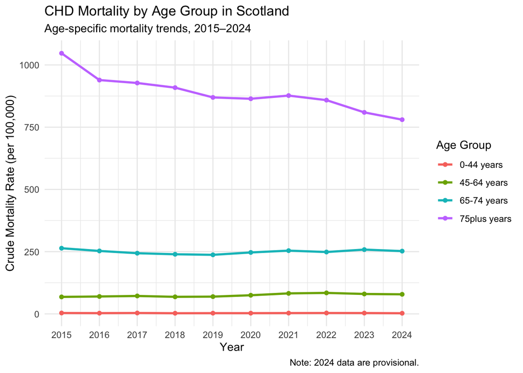

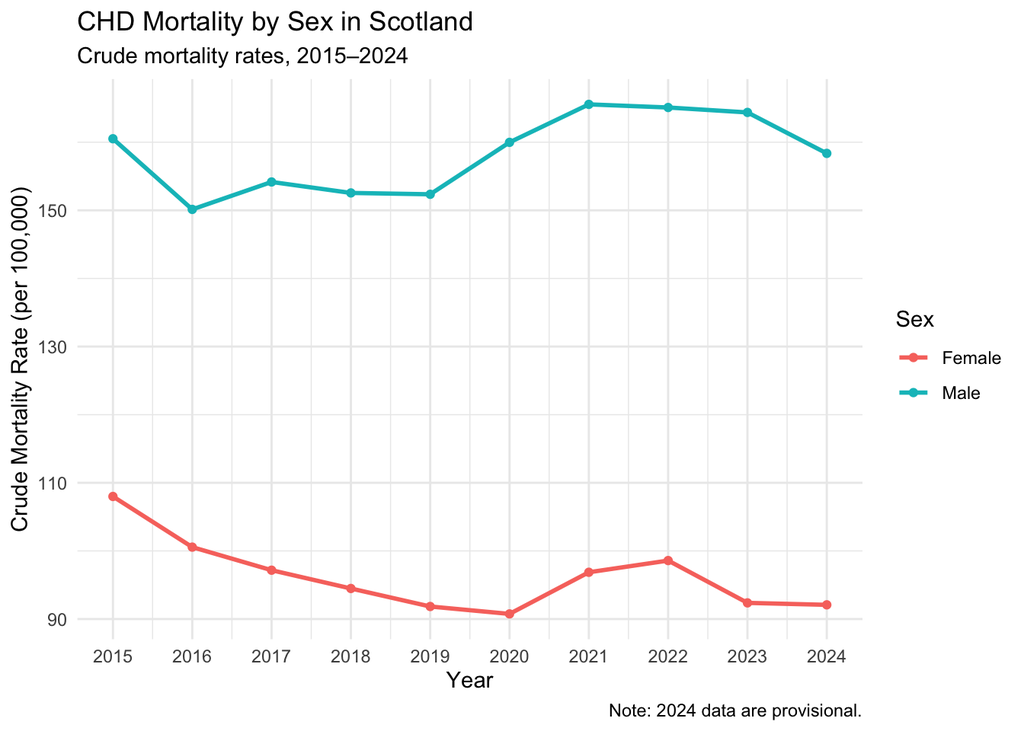

### Geographical Differences Across Council Areas

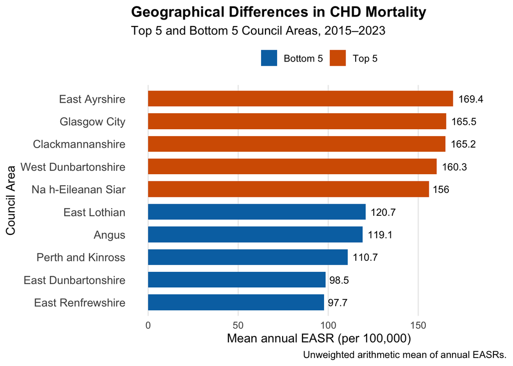

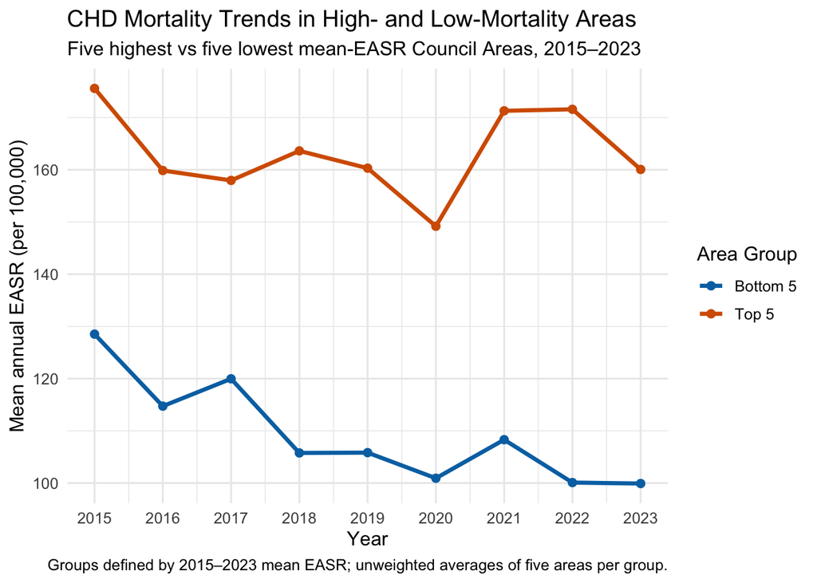

## Linear Regression Analysis

### Regional Modelling: Simple vs. Multiple Linear Regression

To quantify the effects of time and geographical location, we used the European Age-Standardised Mortality Rate (easr) across the 10 selected Council Areas (2015–2023) as our response variable.

#### Simple Linear Regression (Model 1)

We first fitted a simple linear regression model using only year to predict CHD mortality rates.

```
##
## Call:
## lm(formula = easr ~ year, data = regression_df)
##
## Residuals:
##     Min      1Q  Median      3Q     Max
## -58.462 -28.730  -3.379  27.457  89.208
##
## Coefficients:
##             Estimate Std. Error t value Pr(>|t|)
## (Intercept) 3521.504   2718.883   1.295    0.199
## year          -1.677      1.347  -1.245    0.216
##
## Residual standard error: 32.99 on 88 degrees of freedom
## Multiple R-squared:  0.01731,    Adjusted R-squared:  0.006144
## F-statistic:  1.55 on 1 and 88 DF,  p-value: 0.2164
```

The following plot shows the observed mortality rates and the fitted regression line.

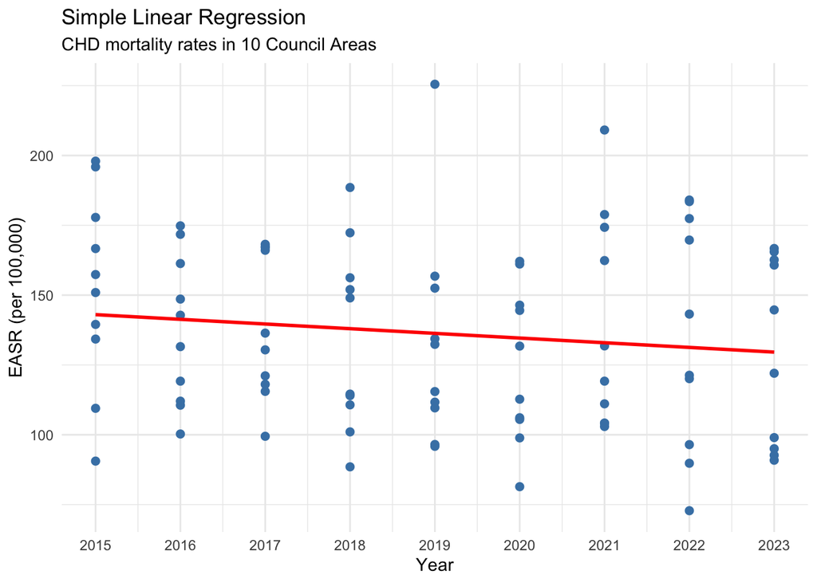

### Limitations of the Simple Model

The simple linear regression plot shows a slight downward trend in CHD mortality rates between 2015 and 2023 ($R^2 = 0.017$, $p = 0.216$). However, the observed mortality rates vary considerably across Council Areas within the same year. This indicates that year alone cannot adequately explain the variation in mortality rates. Therefore, we extended the model by including Council Area (area) as an additional predictor.

#### Multiple Linear Regression (Model 2)

The multiple linear regression model includes both year and area, capturing the overall relationship between time and mortality rates while accounting for baseline differences between regions.

```
##
## Call:
## lm(formula = easr ~ year + area, data = regression_df)
##
## Residuals:
##     Min      1Q  Median      3Q     Max
## -47.406 -11.527  -1.644   8.014  60.361
##
## Coefficients:
##                          Estimate Std. Error t value Pr(>|t|)
## (Intercept)             3504.2792  1466.8307   2.389   0.0193 *
## year                      -1.6767     0.7265  -2.308   0.0236 *
## areaClackmannanshire      46.0715     8.3890   5.492 4.68e-07 ***
## areaEast Ayrshire         50.3360     8.3890   6.000 5.64e-08 ***
## areaEast Dunbartonshire  -20.6068     8.3890  -2.456   0.0162 *
## areaEast Lothian           1.6244     8.3890   0.194   0.8470
## areaEast Renfrewshire    -21.3906     8.3890  -2.550   0.0127 *
## areaGlasgow City          46.4004     8.3890   5.531 3.99e-07 ***
## areaNa h-Eileanan Siar    36.9376     8.3890   4.403 3.31e-05 ***
## areaPerth and Kinross     -8.3330     8.3890  -0.993   0.3236
## areaWest Dunbartonshire   41.2082     8.3890   4.912 4.77e-06 ***
## ---
## Signif. codes:  0 '***' 0.001 '**' 0.01 '*' 0.05 '.' 0.1 ' ' 1
##
## Residual standard error: 17.8 on 79 degrees of freedom
## Multiple R-squared:  0.7432, Adjusted R-squared:  0.7107
## F-statistic: 22.87 on 10 and 79 DF,  p-value: < 2.2e-16
```

### Multiple Regression Plot

The plot below uses the fitted multiple regression model to display the predicted mortality trends for each Council Area. Because the model uses a common year coefficient ($\beta_{\text{year}} = -1.677$, $p = 0.024$), the fitted lines share the same downward slope but have distinct intercepts reflecting regional differences.

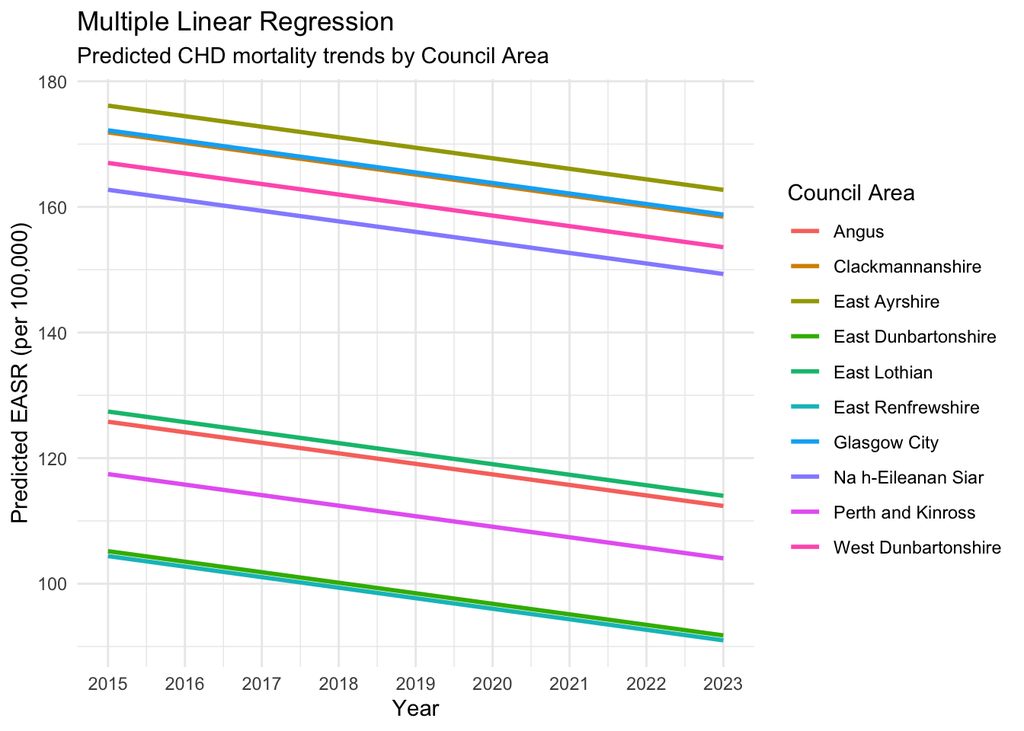

### Actual vs Predicted Mortality Rates

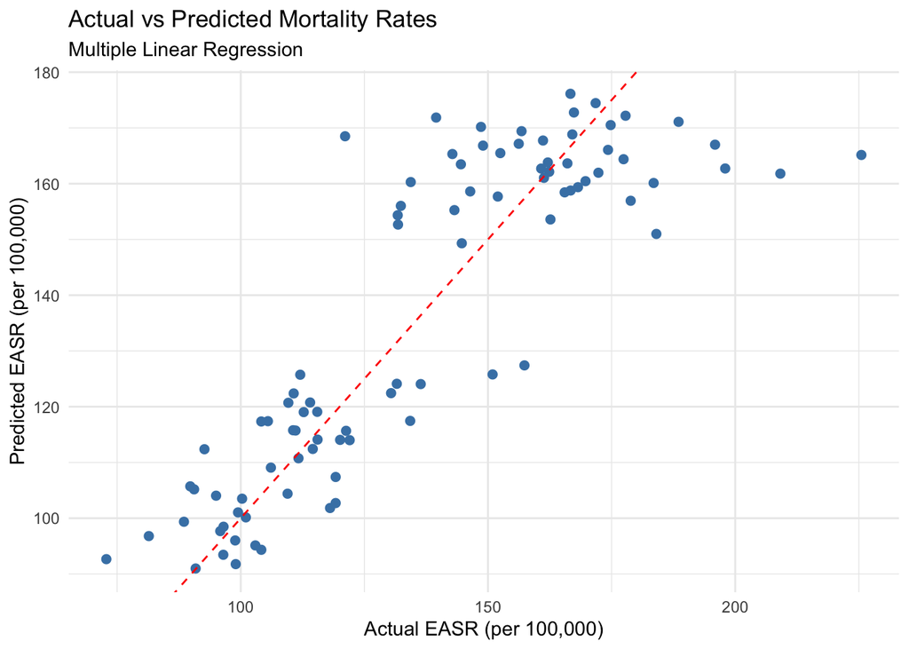

The dashed red line represents perfect predictions. Points closer to this line indicate smaller prediction errors.

### Regional Model Comparison

We compared the two regional models using $R^2$, adjusted $R^2$, and residual standard error. A higher adjusted $R^2$ indicates that the model explains more variation after accounting for the number of predictors, while a lower residual standard error reflects closer alignment with observed rates.

Comparison of Linear Regression Models

| Model | R_squared | Adjusted_R_squared | Residual_SE |
| --- | --- | --- | --- |
| Simple | 0.017 | 0.006 | 32.986 |
| Multiple | 0.743 | 0.711 | 17.796 |

### Demographic Modelling: Age, Sex, and Interaction Effects

Next, we examined how demographic factors influence national crude mortality rates (crude_rate) between 2015 and 2023, centering year at 2015 (year_centered = year - 2015).

We first fitted an additive model (Model 3: crude_rate ~ year_centered + age_group + gender), which assumes a constant mortality gap between males and females across all age groups. However, checking the mean mortality rates by age and sex shows that the sex gap widens dramatically with age—from 3.45 per 100,000 in the 0-44 years group to 419.57 per 100,000 in the 75plus years group.

```
##
## Call:
## lm(formula = crude_rate ~ year_centered + age_group + gender,
##     data = demographic_df)
##
## Residuals:
##      Min       1Q   Median       3Q      Max
## -202.144  -68.433    2.614   69.456  236.753
##
## Coefficients:
##                       Estimate Std. Error t value Pr(>|t|)
## (Intercept)            -66.606     28.372  -2.348   0.0219 *
## year_centered           -5.292      4.039  -1.310   0.1947
## age_group45-64 years    72.388     29.500   2.454   0.0168 *
## age_group65-74 years   250.967     29.500   8.507 3.28e-12 ***
## age_group75plus years  932.312     29.500  31.604  < 2e-16 ***
## genderMale             181.954     20.860   8.723 1.35e-12 ***
## ---
## Signif. codes:  0 '***' 0.001 '**' 0.01 '*' 0.05 '.' 0.1 ' ' 1
##
## Residual standard error: 88.5 on 66 degrees of freedom
## Multiple R-squared:  0.9526, Adjusted R-squared:  0.949
## F-statistic: 265.3 on 5 and 66 DF,  p-value: < 2.2e-16
```

```
## # A tibble: 4 × 4
##   age_group    Female    Male    Gap
##   <fct>         <dbl>   <dbl>  <dbl>
## 1 0-44 years     1.48    4.93   3.45
## 2 45-64 years   33.9   117.    83.4
## 3 65-74 years  143.    365.   221.
## 4 75plus years 726.   1145.   420.
```

To capture this compounding effect, we introduced an interaction term between age group and sex (Model 4: crude_rate ~ year_centered + age_group * gender).

```
##
## Call:
## lm(formula = crude_rate ~ year_centered + age_group * gender,
##     data = demographic_df)
##
## Residuals:
##    Min     1Q Median     3Q    Max
## -83.33 -16.31  -3.22  15.24 139.28
##
## Coefficients:
##                                  Estimate Std. Error t value Pr(>|t|)
## (Intercept)                        22.649     12.557   1.804 0.076076 .
## year_centered                      -5.292      1.508  -3.509 0.000836 ***
## age_group45-64 years               32.398     15.576   2.080 0.041595 *
## age_group65-74 years              142.002     15.576   9.117 4.06e-13 ***
## age_group75plus years             724.249     15.576  46.499  < 2e-16 ***
## genderMale                          3.446     15.576   0.221 0.825633
## age_group45-64 years:genderMale    79.980     22.027   3.631 0.000568 ***
## age_group65-74 years:genderMale   217.928     22.027   9.894 1.90e-14 ***
## age_group75plus years:genderMale  416.125     22.027  18.891  < 2e-16 ***
## ---
## Signif. codes:  0 '***' 0.001 '**' 0.01 '*' 0.05 '.' 0.1 ' ' 1
##
## Residual standard error: 33.04 on 63 degrees of freedom
## Multiple R-squared:  0.9937, Adjusted R-squared:  0.9929
## F-statistic:  1241 on 8 and 63 DF,  p-value: < 2.2e-16
```

An Analysis of Variance (ANOVA) comparing Model 3 and Model 4 confirms that adding the interaction term significantly improves model fit ($F = 136.84$, $p < 2.2 \times 10^{-16}$), substantially reducing the residual sum of squares (RSS) and increasing adjusted $R^2$ from 0.9490 to 0.9929.

```
## Analysis of Variance Table
##
## Model 1: crude_rate ~ year_centered + age_group + gender
## Model 2: crude_rate ~ year_centered + age_group * gender
##   Res.Df    RSS Df Sum of Sq      F    Pr(>F)
## 1     66 516926
## 2     63  68776  3    448150 136.84 < 2.2e-16 ***
## ---
## Signif. codes:  0 '***' 0.001 '**' 0.01 '*' 0.05 '.' 0.1 ' ' 1
```

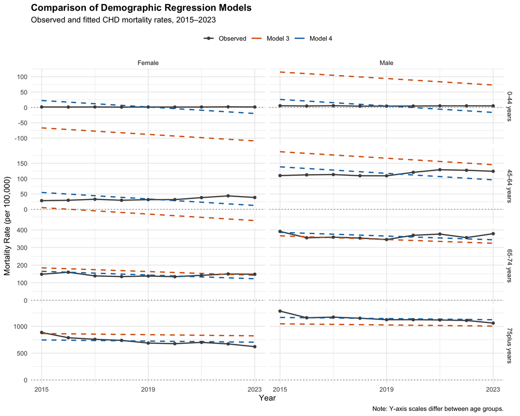

Comparison of Demographic Regression Models

| Model | R_squared | Adjusted_R_squared | Residual_SE | RSS |
| --- | --- | --- | --- | --- |
| Model 3 | 0.9526 | 0.9490 | 88.4998 | 516926.00 |
| Model 4 | 0.9937 | 0.9929 | 33.0407 | 68776.43 |

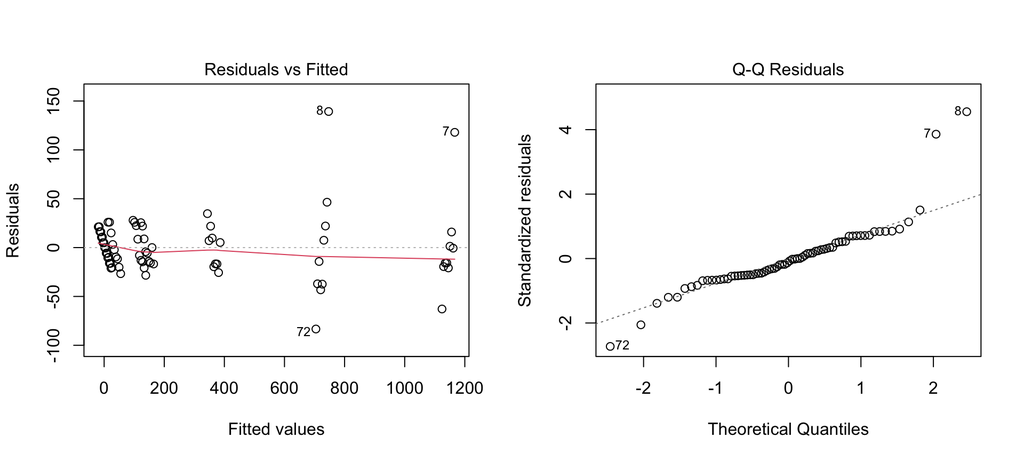

### Model Diagnostics

Finally, we evaluated residual behaviour to check the underlying assumptions of our linear models:

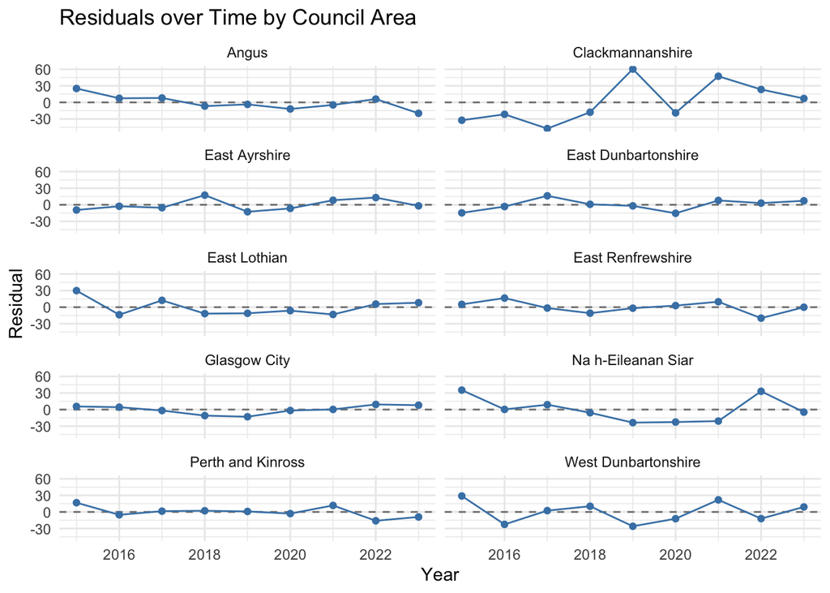

```
## # A tibble: 10 × 2
##    area                lag1_cor
##    <chr>                  <dbl>
##  1 Glasgow City          0.614
##  2 Angus                 0.284
##  3 Na h-Eileanan Siar    0.0879
##  4 Clackmannanshire      0.0730
##  5 East Dunbartonshire  -0.0350
##  6 East Renfrewshire    -0.0832
##  7 East Ayrshire        -0.203
##  8 Perth and Kinross    -0.261
##  9 East Lothian         -0.426
## 10 West Dunbartonshire  -0.537
```

```
## [1] NA 12  8  5 -3
```

## Summary of Findings

Our findings show that while overall CHD mortality in Scotland declined between 2015 and 2023, both geographical location and demographic characteristics strongly shape mortality outcomes:

1. Geographical Variation: Adding Council Area to the regional regression model increased $R^2$ from 0.017 to 0.743 (and adjusted $R^2$ from 0.006 to 0.711), while reducing the residual standard error from 32.986 to 17.796. This confirms that regional disparities account for the majority of variation across these areas.
2. Demographic Interaction: Incorporating the interaction between age group and sex significantly improved the demographic model ($R^2 = 0.9937$), demonstrating that the excess mortality experienced by males widens substantially in middle and older age groups rather than remaining constant.

## Limitations and Ethical Considerations

1. Subset Selection: The regional regression models only included ten Council Areas selected from the highest and lowest mortality extremes. Therefore, the findings may not represent intermediate regions across Scotland.
2. Linear Model Assumptions: Assuming a single constant annual slope across all regions and demographic cohorts can lead to residual autocorrelation and unrealistic negative rate predictions in low-mortality groups (0-44 years females). Future work could apply Poisson or generalised linear models to address non-negativity and heteroscedasticity.
3. Aggregated Data and Ethics: Because the dataset consists of publicly available, aggregated population statistics from Public Health Scotland, there are no individual privacy concerns. However, because the data are aggregated at the Council Area level, we cannot infer individual-level risk factors (such as smoking or socioeconomic deprivation), and care should be taken to interpret regional differences in terms of healthcare resource allocation rather than stigmatising specific communities.

(Note: Generative AI was used to assist with R code debugging and improving the clarity of written explanations.)

## References

1. Heart Disease and Stroke Team (2026) Heart Disease Mortality by Council Area Version 2.0. Scottish Health and Social Care Open Data. https://www.opendata.nhs.scot/dataset/scottish-heart-disease-statistics
2. Scottish Government (2026) Data Zone 2022. Scottish Health and Social Care Open Data. https://www.opendata.nhs.scot/dataset/geography-codes-and-labels/resource/4ba68159-7373-4f73-9429-bf4018b00357